# chapter3

Alena Konina

11/17/2019

# Chapter 3. Logistic regression. Analysis

This data approach student achievement in secondary education of two Portuguese schools. The data attributes include student grades, demographic, social and school related features; it was collected by using school reports and questionnaires.

```r
alc <- read.csv("./data/alc.csv")
```

The dataset contains 35 variables and 382 observations pertaining to the performance, family, personal life and other information about students and their consumption of alcohol.

Here, I am interested in studying the relationships between **high/low alcohol consumption** and other variables in the data, namely, four of them: ‘absences’ (number of school absences), ‘traveltime’ (home to school travel time), ‘goout’ (going out with friends), and ‘famrel’ (quality of family relationships).

I hypothesize that the high number of absences and a lot of time with friends along with bad family relationships and short traveltime will increase odds of high alcohol consumption in students.

```r
library(dplyr)
keep_columns <- c("sex", "age", "absences", "traveltime", "goout", "famrel", "high_use")
alc <- select(alc, one_of(keep_columns))
sex <- alc$sex
age <- alc$age
absences <- alc$absences
traveltime <- alc$traveltime
goout <- alc$goout
famrel <- alc$famrel
high_use <- alc$high_use
```

We have now reformatted the dataset to only keep the columns pertaining to the hypothesis and two general variables, sex and age. Now onto the graphical exploration.

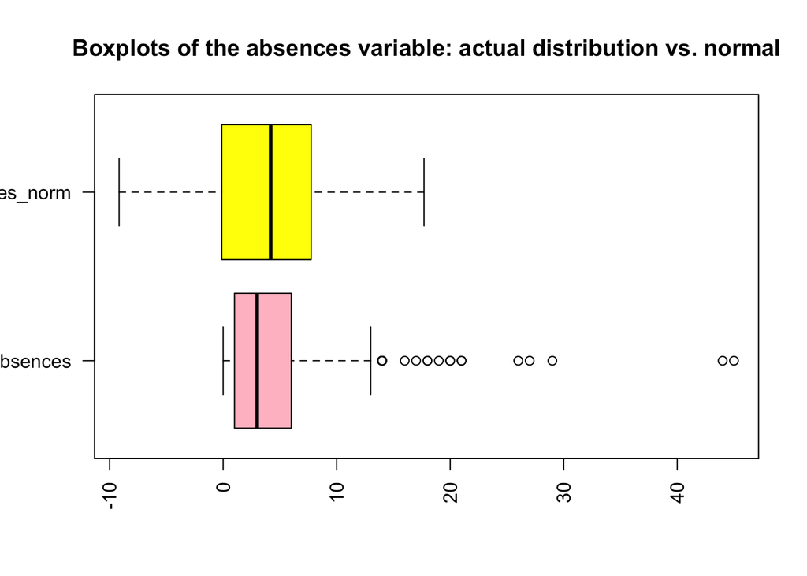

```r
library(ggplot2)
# create a dummy variable with the same mean and standard deviation, but normally distributed, for comparison purposes
absences_norm <- rnorm(200,mean=mean(absences, na.rm=TRUE), sd=sd(absences, na.rm=TRUE))
# plot the two variables side by side
boxplot(absences, absences_norm, main = "Boxplots of the absences variable: actual distribution vs. normal", at = c(1,2), names = c("absences","absences_norm"), las = 2, col = c("pink","yellow"), horizontal = TRUE)
```

First, we need to analyze the only numeric variable, the number of absences. As seen in the boxplot, the actual distribution is within normal limits (with no negative values) and with a few outliers. Before excluding those observations, we will explore other variable and try and fit the model.  
Now we will plot the interval variables with a scale of answers from 1 to 5.

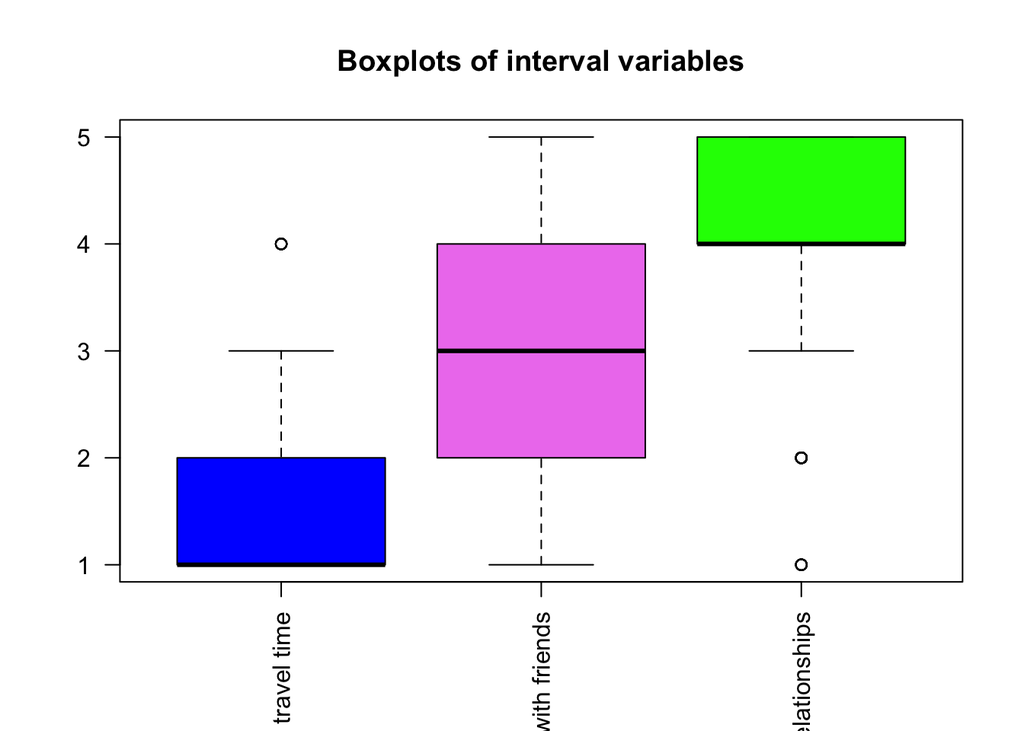

```r
boxplot(traveltime, goout, famrel, main = "Boxplots of interval variables", at = c(1,2,3), names = c("travel time","time with friends", "family relationships"), las = 2, col = c("blue","violet","green"))
```

The “goout” variable seems to be distributed normally, although two others are skewed in different directions. Next, we will plot each variable against the response variable and explore the dataset further.

```r
library(GGally)
```

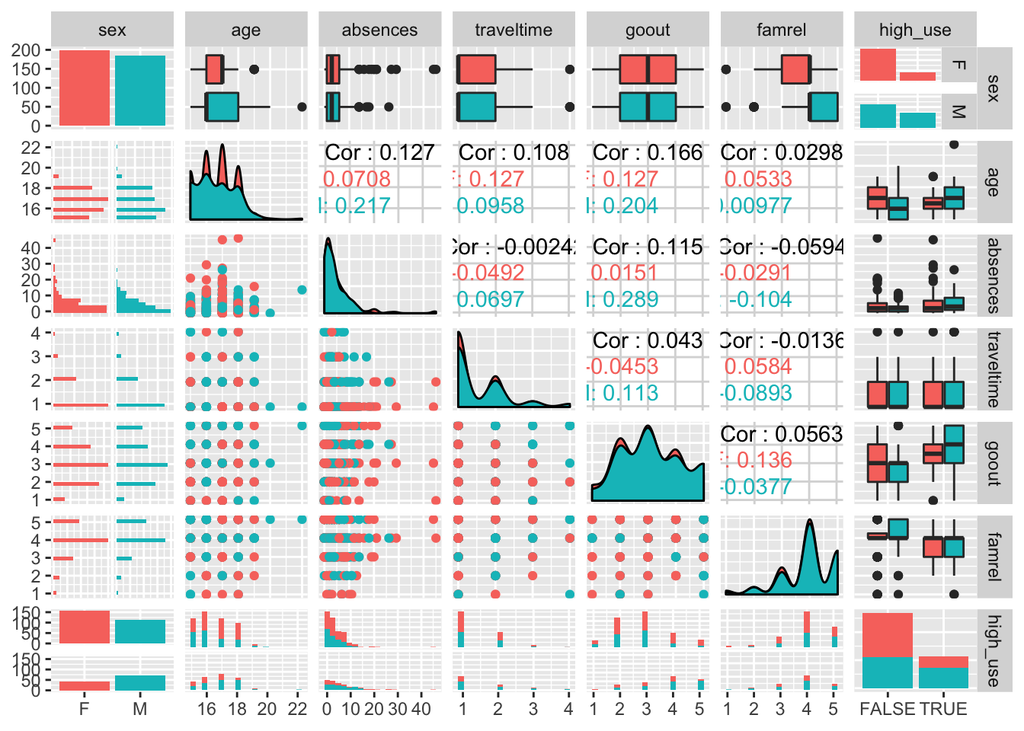

```r
cross <- ggpairs(alc, mapping = aes(col = sex), lower = list(combo = wrap("facethist", bins = 20)))
cross
```

The variables have very low correlation values between themselves, so there is no risk of covariance tamperinf with the model. Now onto the model fitting.

```r
m <- glm(high_use ~ absences + traveltime + goout + famrel, data = alc, family = "binomial")
summary(m)
```

```
##
## Call:
## glm(formula = high_use ~ absences + traveltime + goout + famrel,
##     family = "binomial", data = alc)
##
## Deviance Residuals:
##     Min       1Q   Median       3Q      Max
## -2.0083  -0.7805  -0.5437   0.8464   2.3984
##
## Coefficients:
##             Estimate Std. Error z value Pr(>|z|)
## (Intercept) -2.97770    0.68176  -4.368 1.26e-05 ***
## absences     0.07559    0.02202   3.432 0.000598 ***
## traveltime   0.43957    0.17532   2.507 0.012167 *
## goout        0.76735    0.12087   6.348 2.18e-10 ***
## famrel      -0.36294    0.13756  -2.638 0.008331 **
## ---
## Signif. codes:  0 '***' 0.001 '**' 0.01 '*' 0.05 '.' 0.1 ' ' 1
##
## (Dispersion parameter for binomial family taken to be 1)
##
##     Null deviance: 465.68  on 381  degrees of freedom
## Residual deviance: 389.46  on 377  degrees of freedom
## AIC: 399.46
##
## Number of Fisher Scoring iterations: 4
```

All of the explanatory variables have a statistically significant relationship with the target variable.  
Next, we will calculate the odds ratios and confidence intervals to validate our model.

```r
odds_ratios <- coef(m) %>% exp
conf_int <- confint(m) %>% exp
cbind(odds_ratios, conf_int)
```

```
##             odds_ratios      2.5 %    97.5 %
## (Intercept)   0.0509099 0.01285711 0.1879144
## absences      1.0785172 1.03437018 1.1291483
## traveltime    1.5520466 1.10198801 2.1968917
## goout         2.1540600 1.71012923 2.7497327
## famrel        0.6956280 0.52984131 0.9103098
```

To continue fitting the model, we will compare predicted and actual values.

```r
# predict the probability of high_use
probabilities <- predict(m, type = "response")

alc <- mutate(alc, probability = probabilities)
# use the probabilities to make a prediction of high_use
alc <- mutate(alc, prediction = (probability > 0.5))
select(alc, absences, traveltime, goout, famrel, high_use, probability, prediction) %>% head(10)
```

```
##    absences traveltime goout famrel high_use probability prediction
## 1         5          2     4      4    FALSE  0.47428353      FALSE
## 2         3          1     3      5    FALSE  0.13895457      FALSE
## 3         8          1     2      4     TRUE  0.13581670      FALSE
## 4         1          1     2      3    FALSE  0.11746601      FALSE
## 5         2          1     2      4    FALSE  0.09079210      FALSE
## 6         8          1     2      5    FALSE  0.09855191      FALSE
## 7         0          1     4      4    FALSE  0.28486278      FALSE
## 8         4          2     4      4    FALSE  0.45548223      FALSE
## 9         0          1     2      4    FALSE  0.07906088      FALSE
## 10        0          1     1      5    FALSE  0.02697575      FALSE
```

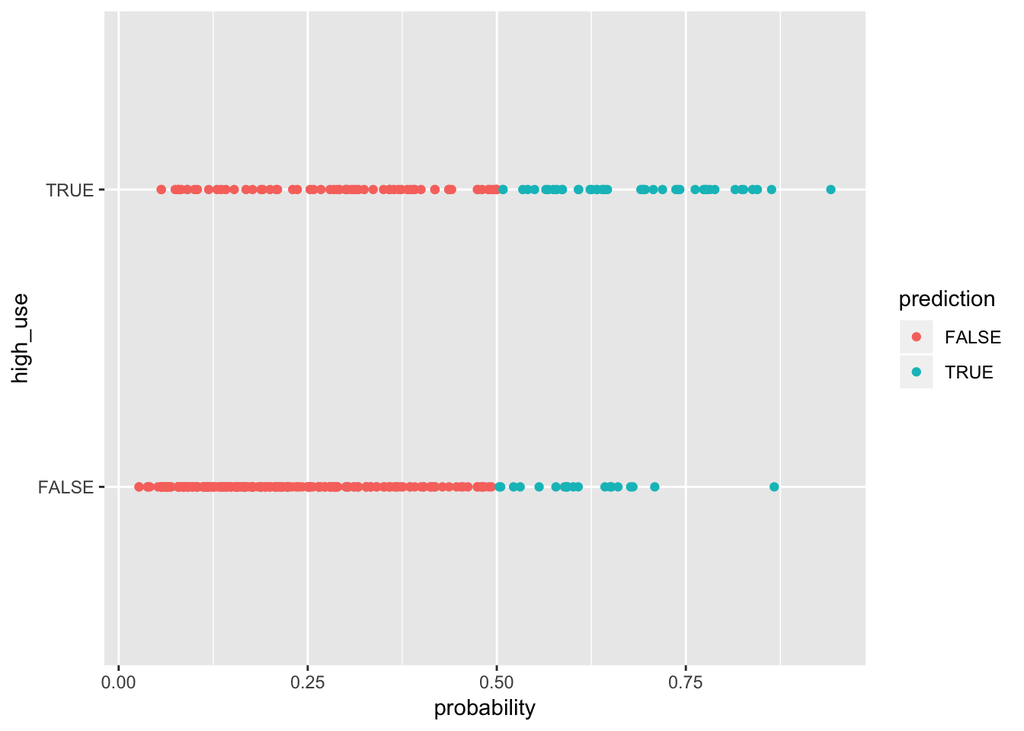

```r
prediction_plot <- ggplot(alc, aes(x = probability, y = high_use, col = prediction))
prediction_plot + geom_point()
```

```r
table(high_use = alc$high_use, prediction = alc$prediction) %>% prop.table() %>% addmargins()
```

```
##         prediction
## high_use      FALSE       TRUE        Sum
##    FALSE 0.64921466 0.05235602 0.70157068
##    TRUE  0.18586387 0.11256545 0.29842932
##    Sum   0.83507853 0.16492147 1.00000000
```

Not totally amazing, but still. The penultimate step would be to calculate the accuracy of the model.

```r
# define a loss function (mean prediction error)
loss_func <- function(class, prob) {
  n_wrong <- abs(class - prob) > 0.5
  mean(n_wrong)
}
# call loss_func to compute the average number of wrong predictions in the training data
loss_func(class = alc$high_use, prob = alc$probability)
```

```
## [1] 0.2382199
```

Quite a good result!  
Finally, we perform the 10-fold cross-validation.

```r
library(boot)
cv <- cv.glm(data = alc, cost = loss_func, glmfit = m, K = 10)

# average number of wrong predictions in the cross validation
cv$delta[1]
```

[output not shown]

Sliiiiightly better than 0.26 by the DataCamp model.